# Decision Trees & Random Forests

## Summary of Report

This section describes the workflow of the following report. In this project we are given a dataset of **2020 student loans** and with the following features being known:

1) Field of study (Humanities, Business, Stem)  
2) Whether the university was selective in its admissions process (0, 1)  
3) Student's gender (male vs. female)  
4) Loan amount  
5) Graduation Year  
6) Whether loan defaulted or not (response variable)

### Objective

Given this dataset we will play with decision tree and random forests classifiers to try to predict whether a loan will default in the future.

### Comments on final results

**Tree classifier**  
We begin by fitting a complete tree to the training dataset. The resulting tree is too big and clearly overfits the training set (visual inspection included) as anticipated. It achieves an **accuracy of 80% on the test set**. We proceed with tuning the tree classifier in hopes of reducing overfitting and achieving a higher accuracy on the test set. To this aim, we are using two tuning parameters, `max_depth` and `ccp_alhpa` (cost-complexity-pruning). These two methods are quite different and result in trees with different depths. **However, both (optimised) trees achieve an accuracy of 86% on the test set**. Nontheless, their **confusion matrices differ** in terms of **precision** and **recall** metrics with respect to default loans. In this case, each bank should choose the model that minimises the tradeoff between falsely flagging a loan that will not default in the future and not identifying a loan that will default in the upcoming years.

Finally, we evaluate whether the training-validation-test set approach or Kfold cross-validation is more suitable for this dataset. It turns out that more data would be ideal for this task. Therefore, KFold cross-validation is performed in order to choose the `max_depth` parameter. We re-fit a new tree which ends up achieving the same accuracy of 86%. Its confusion matrix is again different to the previous ones.

**Random Forests**  
We proceed by fitting a random forest model to the data. We begin by finding a suitable number of estimators (trees) to be grown during the training phase. Due to the small number of features available and the limited size of the dataset we show that 20 trees are enough. We then proceed with a full grid search using crosss-validation for specific parameter value ranges. We are considering `n_estimators`, `max_depth` and `max_features`. **The performance of the random forest model is slighly better compared to the single tree, achieving an accuracy of 87% on the test set**. Its **confusion matrix is yet again different** to the ones resulting from single tree classifiers, yet, it is **more balanced**.

Finally, we use two methods, `feature_importances_` and partial dependence plots `PartialDependenceDisplay.from_estimator`, to get a good idea of the importance of each feature on the information gain and influence on the predicted outcomes, respectively. Feature importance is widely used as a dimensionality reduction method, used in practice so limit the amount of features to the ones that are truly relevant for the response variable. Partial dependency plots are used to illustrate the functional relationship (linear vs. non-linear) between individual (or pairs of) features and the predicted variable.

# 0. Preparation

## 0.1 Import the usual libraries for pandas and plotting. You can import sklearn later on.**

```python
import numpy as np
import pandas as pd
import matplotlib.pyplot as plt
import seaborn as sns
```

## 0.2 Get the Data

**Use pandas to read loan_data.csv as a dataframe called loans.**

```python
loans = pd.read_csv('loandata.csv')
loans = loans.sample(frac=1, random_state=5)
```

**Check out the info(), head(), and describe() methods on loans.**

```python
loans.info()
```

```
<class 'pandas.core.frame.DataFrame'>
Int64Index: 2020 entries, 886 to 867
Data columns (total 6 columns):
 #   Column            Non-Null Count  Dtype
---  ------            --------------  -----
 0   field             2020 non-null   object
 1   selectiveCollege  2020 non-null   int64
 2   sex               2020 non-null   object
 3   Default           2020 non-null   object
 4   loanAmount        2020 non-null   int64
 5   graduationYear    2020 non-null   int64
dtypes: int64(3), object(3)
memory usage: 110.5+ KB
```

```python
loans.describe()
```

|  | selectiveCollege | loanAmount | graduationYear |
| --- | --- | --- | --- |
| count | 2020.000000 | 2020.000000 | 2020.000000 |
| mean | 0.200495 | 48796.975743 | 2009.491584 |
| std | 0.400470 | 11029.278956 | 3.037234 |
| min | 0.000000 | 2002.000000 | 1994.000000 |
| 25% | 0.000000 | 40966.750000 | 2007.000000 |
| 50% | 0.000000 | 48220.500000 | 2010.000000 |
| 75% | 0.000000 | 55873.250000 | 2012.000000 |
| max | 1.000000 | 90699.000000 | 2020.000000 |

```python
loans.head()
```

|  | field | selectiveCollege | sex | Default | loanAmount | graduationYear |
| --- | --- | --- | --- | --- | --- | --- |
| 886 | STEM | 0 | Male | No | 52810 | 2015 |
| 733 | STEM | 0 | Male | No | 32831 | 2012 |
| 802 | HUMANITIES | 1 | Male | No | 71065 | 2011 |
| 1735 | STEM | 0 | Female | No | 62599 | 2009 |
| 419 | STEM | 0 | Male | No | 66905 | 2005 |

# 1. Exploratory Data Analysis

## 1.1 Ιntroduction

Exploratory Data Analysis is a great tool for the user to get an idea of the data before deploying a ML algorithm. By visually inspecting data, the user gets to confirm and dispute some hypotheses/expectations and come up with new ones. Visualisation is mainly used for validating prior beliefs, but, perhaps more importantly, it should be used for discovering unexpected relationships too (which previously seemed counter-intuitive).

Unfortunately, for the best performing ML algorithms in terms of prediciton accuracy, it is usually very difficult to decompose the final prediction. Ensemble, methods such as *Bagging Classifiers*, *Random Forests* and *Boosted Classifiers* are averaging predictions coming from many weak learners (usually >100 *weak* learners) and thus the user is unable to deconstruct and backtrack the algorithms prediction. It is quite important to get an idea first before blindly testing the algorithms predictions.

In this Section, we will go through some of my own investigatory questions that I have come up with!

## 1.2 Visualisations and Insights

```python
plt.rcParams["figure.figsize"] = (10,6)
```

**1) How many defaults do we have?**

```python
print('Percentage of no defaults', round(loans['Default'].value_counts()[0]/len(loans),2)*100,'%')
```

```
Percentage of no defaults 76.0 %
```

Overall, only 24% of loans included in the dataset defaulted! The percentage of non-defaults is our benchmark, namely 76%, based on which we compare the ML algorithms.

**2) Do loans associated with a higher lent amounts default more easily?**

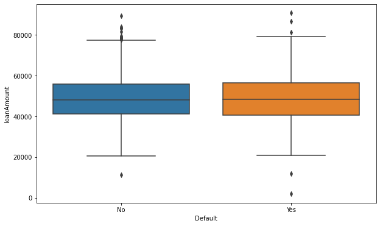

```python
sns.boxplot(data=loans, y='loanAmount', x='Default')
```

It seems that loan amount does not provide some discriminative value at the overview level!

**3) Did students default more often in specific graduation years?** (Think of global economic crisis)

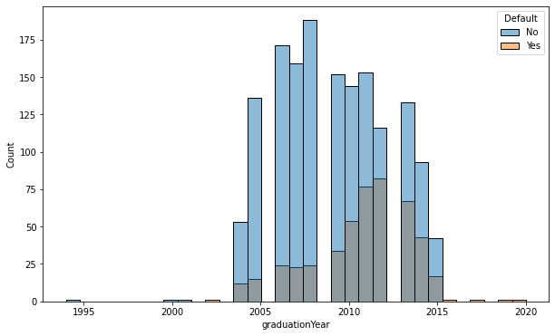

```python
sns.histplot(data=loans, x='graduationYear', hue='Default')
```

**Does the field of study affect the probability of defaulting?**

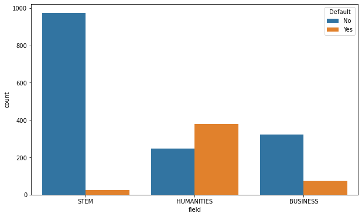

```python
sns.countplot(data=loans, x='field', hue='Default')
```

By comparing the height of the yellow vs. blue bars for each study field, we can easily identify that humanitarian studies pose a potential subgroup of students who are more prone to defaulting. In fact, the percentage of students in *Humanities* that defaulted is higher than the one concerning those that did not. The relationship of the respective percentages is opposite for the other two fields. The probability of defaulting is significantly lower than that of non-defaults.

**4) Do male and female students in this dataset exhibit the same probability of defaulting?**

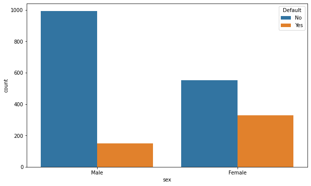

```python
sns.countplot(data=loans, x='sex', hue='Default',)
```

```python
print('Percentage of female students that did default',
      round(len(loans[(loans['sex']=='Female') & (loans['Default']=='Yes')]) / len(loans[loans['sex']=='Female']) *100,2),
      '%')
```

```
Percentage of female students that did default 37.32 %
```

```python
print('Percentage of male students that did default',
      round(len(loans[(loans['sex']=='Male') & (loans['Default']=='Yes')]) / len(loans[loans['sex']=='Male'])*100,2),
      '%')
```

```
Percentage of male students that did default 13.06 %
```

It seems that more female than students defaulted in our dataset. However, this is not!! in fact indicating that female students should be trusted less than male students.

**Correlation vs. Causation** : A great example!

This is one of the most frequent examples of the correlation vs. causation pitfall. That is, female students might be prone to default more freuqently exactly because they prefer humanitarian studies. As we have seen earlier, students in *Humanities* default significantly more frequently. We will verify this with a few more plots!

**5) Do female students prefer Humanities over other study fields?**

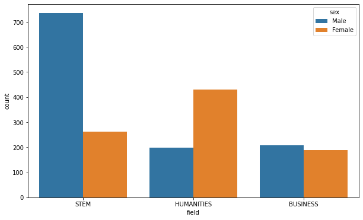

```python
sns.countplot(data=loans, x='field', hue='sex')
```

**6) Do female students default more frequently than male students in Humanities?**

```python
loans_humanities = loans[loans['field']=='HUMANITIES']
```

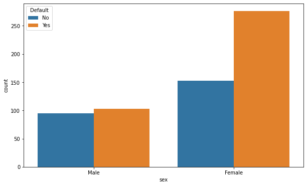

```python
sns.countplot(data=loans_humanities, x='sex', hue='Default')
```

According to the plot, *male* students in **Humanities** have a default rate of roughly 50% whereas *female* students around 65%.

**7) Is the same relationship true for all field studies?**

Instead of creating three filtered dataframes, we can demonstrate the use of `.groupby` method!

```python
loans.head(1)
```

|  | field | selectiveCollege | sex | Default | loanAmount | graduationYear |
| --- | --- | --- | --- | --- | --- | --- |
| 886 | STEM | 0 | Male | No | 52810 | 2015 |

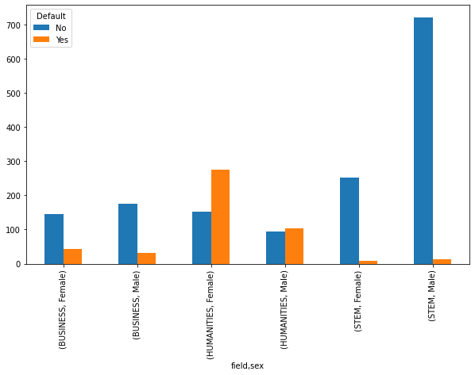

```python
loans_by_field_sex = loans.groupby(by= ['field','sex'])['Default'].value_counts().unstack(2).plot.bar()
```

Overall, in all three study fields (*Humanities, Business, STEM*), male students have lower default rates than women. Still, in *STEM* and *Business* related fields the default rate was signficantly lower than the non-default rate for both female and male students.

**8) Does attending a selective College affect the default probability for humanitarian studies?**

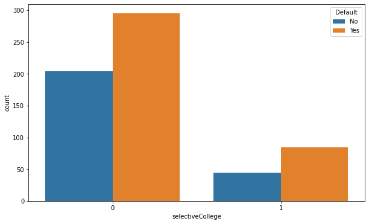

```python
sns.countplot(data=loans_humanities, x='selectiveCollege', hue='Default')
```

Not really! It seems that students in humanitarian studies are facing an overall issue with the job market (potentially low employment rates, or low salaries, or both, etc.)

## 1.3 Summary

By exploring the data, we now have a much more concrete idea of what is going on (still not the full picture).

# 2. Feature Engineering

One-hot encode fields sex, field and Default

```python
cats_feats = ['sex', 'field', 'Default']
final_data = pd.get_dummies(loans, columns=cats_feats, drop_first=True)
```

```python
final_data.head(2)
```

|  | selectiveCollege | loanAmount | graduationYear | sex_Male | field_HUMANITIES | field_STEM | Default_Yes |
| --- | --- | --- | --- | --- | --- | --- | --- |
| 886 | 0 | 52810 | 2015 | 1 | 0 | 1 | 0 |
| 733 | 0 | 32831 | 2012 | 1 | 0 | 1 | 0 |

# 3. Train Test Split

Now its time to split our data into a training set and a testing set!

```python
from sklearn.model_selection import train_test_split
```

```python
X = final_data.drop(columns=['Default_Yes'])
y = final_data['Default_Yes']
```

```python
X_train, X_test, y_train, y_test = train_test_split(X, y, test_size=0.33, random_state=42)
```

```python
print('Size of training set:', len(X_train))
print('Size of test set:', len(X_test))
```

```
Size of training set: 1353
Size of test set: 667
```

# 4. Decision Tree Classifier

```python
from sklearn.tree import DecisionTreeClassifier
from sklearn import tree
```

## 4.1 Train a complete tree classifier

```python
dtree = DecisionTreeClassifier(random_state=2)
```

```python
dtree.fit(X_train,y_train)
```

```
DecisionTreeClassifier(random_state=2)
```

```python
dtree.get_depth()
```

```
18
```

## 4.2 Performance Evaluation for complete tree

```python
from sklearn.metrics import classification_report, confusion_matrix
```

### 4.2.1 Perfomance on training set

```python
predictions_train = dtree.predict(X_train)
```

```python
print(classification_report(y_train,predictions_train))
```

```
              precision    recall  f1-score   support

           0       1.00      1.00      1.00      1036
           1       1.00      1.00      1.00       317

    accuracy                           1.00      1353
   macro avg       1.00      1.00      1.00      1353
weighted avg       1.00      1.00      1.00      1353
```

We are clearly overfitting!

### 4.2.2 Perfomance on test set

```python
predictions = dtree.predict(X_test)
```

```python
print(classification_report(y_test,predictions))
```

```
              precision    recall  f1-score   support

           0       0.87      0.86      0.87       507
           1       0.58      0.60      0.59       160

    accuracy                           0.80       667
   macro avg       0.73      0.73      0.73       667
weighted avg       0.80      0.80      0.80       667
```

### 4.2.3 Classification Report Inisghts

**Missclassification Rate**

- *Accuracy* at 80%, i.e., 20% of all loans were missclassified

**Default Loans (=1)**

- *Precision* = of 58%, i.e., 42% of loans classified as default did not actually default. That means that using this classifier the bank expects that from all loans that it will flag and further examine in the future, 42% will not actually default in the following years.
- *Recall* of 60%, i.e., 40% of loans classified as non-default did actually default. That means that using this classifier the bank will expect to identify 59% of all student loans that will actually turn out to default.

```python
print(confusion_matrix(y_test,predictions))
```

```
[[437  70]
 [ 64  96]]
```

## 4.3 Tuning a decision tree classifier using training and validation set

### 4.3.1 Tree `max_depth` parameter

```python
X_train2, X_val, y_train2, y_val = train_test_split(X_train, y_train, test_size=0.25, random_state=42)
```

```python
print('Size of training set:', len(X_train2))
print('Size of validation set:', len(X_val))
```

```
Size of training set: 1014
Size of validation set: 339
```

```python
from sklearn.metrics import accuracy_score
```

```python
validation_accuracy = [] # list of accuracy scores on validation set
training_accuracy = [] # list of accuracy scores on training set

full_depth = dtree.get_depth()

for depth in range(1,full_depth):

    dtree_tuned = DecisionTreeClassifier(max_depth = depth, random_state=2)

    dtree_tuned.fit(X_train2,y_train2)

    predictions_tuned_val = dtree_tuned.predict(X_val)
    predictions_tuned_train = dtree_tuned.predict(X_train2)

    validation_accuracy.append(accuracy_score(y_val,predictions_tuned_val))
    training_accuracy.append(accuracy_score(y_train2,predictions_tuned_train))
```

### 4.3.2 Plot Validation vs Training Accuracy

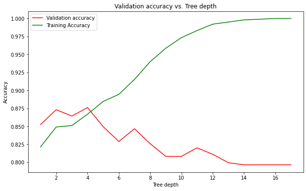

```python
plt.rcParams["figure.figsize"] = (10,6)

plt.plot(range(1,full_depth), validation_accuracy, color='red')
plt.plot(range(1,full_depth), training_accuracy, color='green')
plt.legend(['Validation accuracy', 'Training Accuracy'])
plt.xlabel('Tree depth')
plt.ylabel('Accuracy')
plt.title('Validation accuracy vs. Tree depth')
```

**Validation Accuracy** We can clearly see that the best accuracy on the validaton set is achieved for a small tree depth around 4 trees. The accuracy is around 86%, which is a good indication that it will perform on the test set as well. After that depth level, it seems that the tree has already started overfitting the dataset

```python
max_val  = max(validation_accuracy)
opt_depth = validation_accuracy.index(max_val) + 1
```

```python
opt_depth
```

```
4
```

### 4.3.3 Evaluate on original test set

We train a tree with `max_depth` = `opt_depth` using the original training set and test it on the original test set.

```python
dtree_opt = DecisionTreeClassifier(max_depth = opt_depth, random_state=2)
dtree_opt.fit(X_train, y_train)
final_preds = dtree_opt.predict(X_test)
```

**Confusion Matrix**

```python
print(confusion_matrix(y_test,final_preds))
```

```
[[488  19]
 [ 73  87]]
```

```python
print(classification_report(y_test,final_preds))
```

```
              precision    recall  f1-score   support

           0       0.87      0.96      0.91       507
           1       0.82      0.54      0.65       160

    accuracy                           0.86       667
   macro avg       0.85      0.75      0.78       667
weighted avg       0.86      0.86      0.85       667
```

## 4.4 Tree Visualisation

```python
from sklearn import tree
```

The tree can be read as follows. Starting from an initial node containing all data, split into two nodes based on whether X[0], that is the first feauture in the training set is below 0.5 or not. Make tree more interpretable by adding feature names, class names and colours

```python
plt.rcParams["figure.figsize"] = (20,12)
```

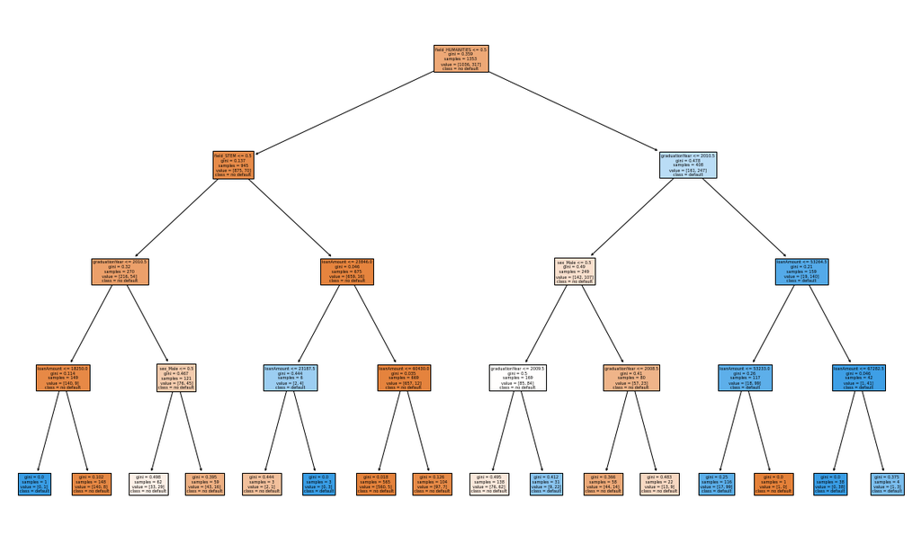

```python
feature_names = X_train.columns
classes = ['no default', 'default']


tree.plot_tree(dtree_opt,
               feature_names = feature_names,
               class_names=classes,
               filled = True);
```

## 4.5 Tuning a tree using cost complexity pruning

[Reference1](https://scikit-learn.org/stable/auto_examples/tree/plot_cost_complexity_pruning.html#sphx-glr-auto-examples-tree-plot-cost-complexity-pruning-py)  
[Reference2](https://scikit-learn.org/stable/modules/tree.html#minimal-cost-complexity-pruning)

Get alpha values and the weighted impurities of leaf nodes resulting from pruning the tree using the respective alhpa value

```python
dtree_ccp = DecisionTreeClassifier(random_state=2)
path = dtree_ccp.cost_complexity_pruning_path(X_train2, y_train2)
ccp_alphas, impurities = path.ccp_alphas, path.impurities
```

For all alpha values obtained in the previous step, fit a new tree and append it to a list of trees called `trees`.

```python
trees = []

for ccp_alpha in ccp_alphas:
    tree_ccp = DecisionTreeClassifier(random_state=2, ccp_alpha=ccp_alpha)
    tree_ccp.fit(X_train2, y_train2)
    trees.append(tree_ccp)

trees = trees[:-1]
ccp_alphas = ccp_alphas[:-1]
```

Evaluate train and validation accuracy for every tree based and plot them

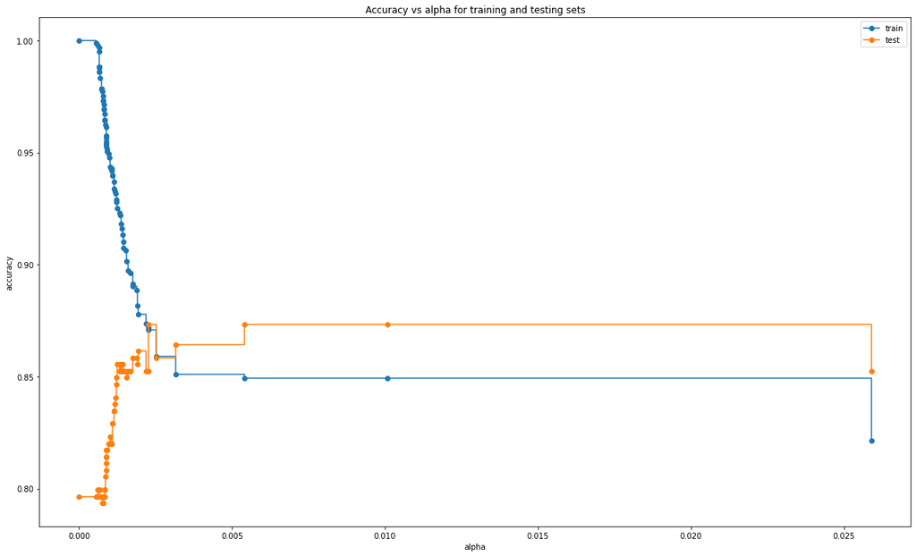

```python
train_scores = [tree.score(X_train2, y_train2) for tree in trees]
val_scores = [tree.score(X_val, y_val) for tree in trees]

fig, ax = plt.subplots()
ax.set_xlabel("alpha")
ax.set_ylabel("accuracy")
ax.set_title("Accuracy vs alpha for training and testing sets")
ax.plot(ccp_alphas, train_scores, marker="o", label="train", drawstyle="steps-post")
ax.plot(ccp_alphas, val_scores, marker="o", label="test", drawstyle="steps-post")
ax.legend()
```

We are interested in the alpha value that leads to the highest validation accuracy. The following code extracts this value

```python
val_score_max = max(val_scores) # get max validation accuracy

val_score_max_index = val_scores.index(val_score_max) # get index

ccp_alpha_opt = ccp_alphas[val_score_max_index] # get optimal alpha value
ccp_alpha_opt
```

```
0.0022616167181723074
```

Fit a new tree with best alpha value

```python
tree_ccp = DecisionTreeClassifier(ccp_alpha = ccp_alpha_opt, random_state=2)
tree_ccp.fit(X_train, y_train)
ccp_preds = tree_ccp.predict(X_test)
```

Get the depth of that tree

```python
tree_ccp.get_depth()
```

```
6
```

```python
print(classification_report(y_test,ccp_preds))
```

```
              precision    recall  f1-score   support

           0       0.87      0.96      0.91       507
           1       0.80      0.54      0.65       160

    accuracy                           0.86       667
   macro avg       0.83      0.75      0.78       667
weighted avg       0.85      0.86      0.85       667
```

```python
print(confusion_matrix(y_test,ccp_preds))
```

```
[[485  22]
 [ 73  87]]
```

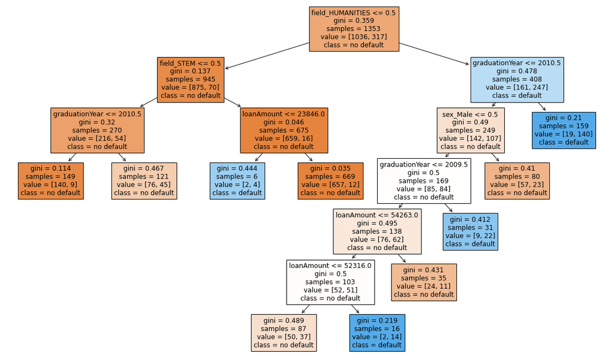

```python
tree.plot_tree(tree_ccp,
               feature_names = feature_names,
               class_names=classes,
               filled = True);
```

This tree has similar performance to the optimal tree based on `max_depth` but still quite a different tree structure. Cost complexity pruning allows for different depths at each side, because it searches for the optimal sub-tree backwards!

## 4.6 Tuning a decision tree classifier using cross-validation

Is it needed? Let's try to estimate this using the learning rate of a tree with depth = 4, that is our estimate for the optimal depth.

### 4.6.1 Inspection

```python
len(X_train)
```

```
1353
```

```python
len(X_train2)
```

```
1014
```

```python
X_train.reset_index(inplace= True)
X_train.drop(columns='index',inplace=True)
y_train.reset_index(drop=True,inplace=True)
```

```python
learning_rate = []

for i in range(200,len(X_train),200):
    exp_tree = DecisionTreeClassifier(max_depth=opt_depth, random_state=2)
    exp_tree.fit(X_train.loc[:i,:], y_train.loc[:i])
    learning_rate.append(exp_tree.score(X_test,y_test))
```

```
(0.75, 1.0)
```

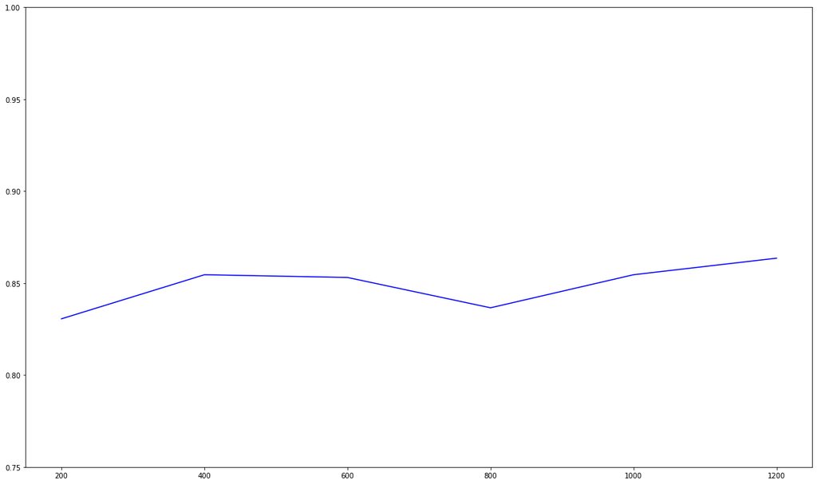

```python
plt.plot(range(200,len(X_train),200), learning_rate, color='blue')
plt.ylim(0.75,1)
```

## 4.6.2 KFold cross validation

```python
from sklearn.model_selection import KFold

kf = KFold(n_splits=5, random_state=10, shuffle=True)
kf.get_n_splits(X)
```

```
5
```

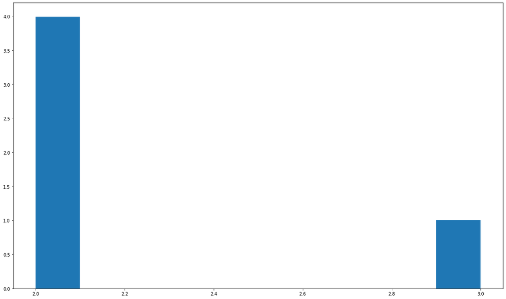

```python
opt_depths = []

for train_index, test_index in kf.split(X):

    X_train, X_test = X.loc[train_index,:], X.loc[test_index,:]
    Y_train, Y_test = y[train_index], y[test_index]

    accuracy_test   = []

    for depth in range(1,21):

        tree = DecisionTreeClassifier(max_depth=depth,random_state=2)
        tree.fit(X_train, Y_train)
        preds_train = tree.predict(X_train)
        preds_val = tree.predict(X_test)
        accuracy_test.append(accuracy_score(Y_test, preds_val)*100)

    opt_depth = np.argmax(np.array(accuracy_test))
    opt_depths.append([opt_depth+1, accuracy_test[opt_depth]])

depths = [i[0] for i in opt_depths]

plt.hist(depths)
```

```python
unique, counts = np.unique(np.array(depths),return_counts=True)
depths_counts = dict(zip(unique, counts))

best_depth = max(depths_counts, key=depths_counts.get)
best_depth
```

```
2
```

```python
accuracy_for_best_depth = [i[1] for i in opt_depths if i[0] == best_depth]
```

```python
np.array(accuracy_for_best_depth).mean()
```

```
86.32425742574256
```

### 4.6.3 Evaluate on initial train-test set

```python
X_train, X_test, y_train, y_test = train_test_split(X, y, test_size=0.33, random_state=42)

tree_cv = DecisionTreeClassifier(max_depth=best_depth, random_state=2)
tree_cv.fit(X_train, y_train)
tree_cv_preds = tree_cv.predict(X_test)
```

```python
print(classification_report(y_test,tree_cv_preds))
```

```
              precision    recall  f1-score   support

           0       0.86      0.97      0.91       507
           1       0.85      0.50      0.63       160

    accuracy                           0.86       667
   macro avg       0.86      0.74      0.77       667
weighted avg       0.86      0.86      0.85       667
```

```python
print(confusion_matrix(y_test,tree_cv_preds))
```

```
[[493  14]
 [ 80  80]]
```

```python
from sklearn import tree
```

```
[Text(0.5, 0.8333333333333334, 'field_HUMANITIES <= 0.5\ngini = 0.359\nsamples = 1353\nvalue = [1036, 317]\nclass = no default'),
```

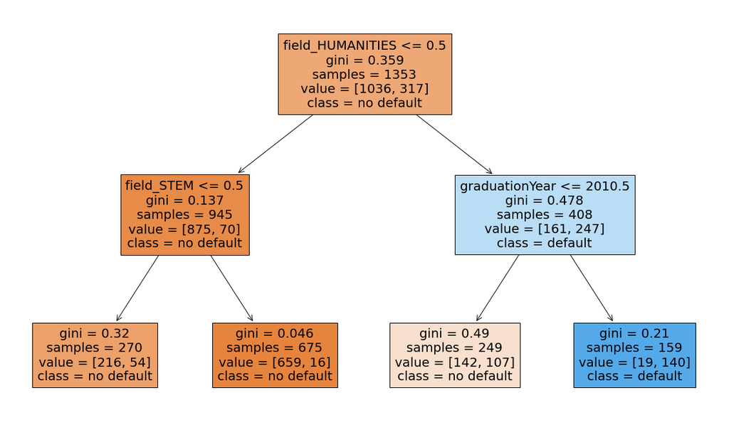

```python
tree.plot_tree(tree_cv,
              feature_names = feature_names,
              class_names = classes,
              filled=True)
```

## 4.7 Conlusion on single Decision Tree Classifier

So far we tried three different methods of tuning the decision tree. In particular we tuned using:

1. `max_depth` with training-validation set
2. cost-complexity tuning with trainin-validation set
3. `max_depth` with KFold cross validation

Every time that we fitted the *optimal tree* according to each methodology, we got a different tree depth and at the end the same missclassification accuracy, **86%**. Precision and Recall metrics were not identical, meaning that the bank could choose which classifier it should use based on the respective costs of failing to identify a loan that will turn out to default, and spending resources on a falsely identified default-prone loan.

In any case, the bank had previously no way of identifying a default-prone loan, as the majority of them were non-defaults. The company should compare the total cost of no-action to the total expected cost of each of these methodologies, and choose the less costly option before deploying the ML method.

All trees are relatively shallow, that means that it is easy to understand and interpret them, which is extremely useful and significant for banks, as they should be able to justify their actions to clients (e.g., not accepting a loan)

# 5. RANDOM FORESTS

```python
from sklearn.ensemble import RandomForestClassifier
```

## 5.1 Inspect accuracy vs. number of estimators (trees)

```python
rf_training_scores = []
rf_validation_scores = []
for i in range(1,200,10):
    rf = RandomForestClassifier(n_estimators=i)
    rf.fit(X_train,y_train)
    rf_training_scores.append(rf.score(X_train,y_train))
    rf_validation_scores.append(rf.score(X_test,y_test))
    rf_preds = rf.predict(X_test)
```

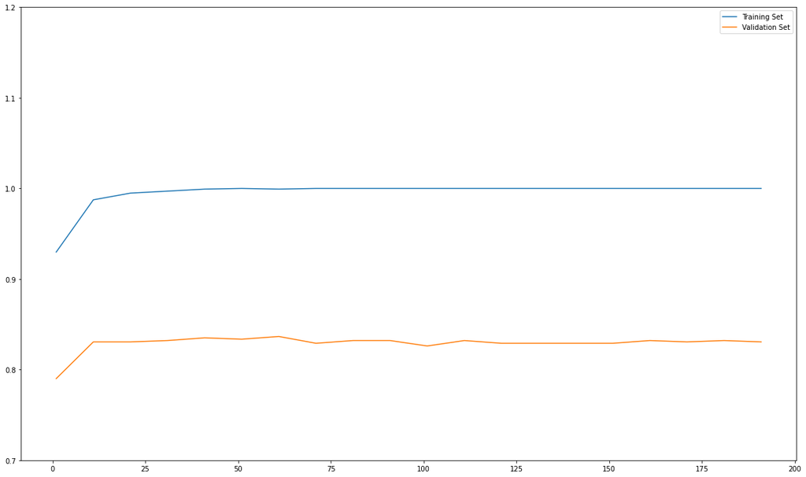

```python
plt.plot(range(1,200,10), rf_training_scores)
plt.plot(range(1,200,10), rf_validation_scores)
plt.ylim((0.7,1.2))
plt.legend(['Training Set', 'Validation Set'])
```

As we increase the trees in Random Forests we do not get a significant difference. We will stay with 20 estimators, since the validation score does not seem to follow an increasing trend afterwards

## 5.2 Fitting a Random Forest model

### 5.2.1 Use all data and Out of bag error

```python
rf_fs = RandomForestClassifier(n_estimators=20,
                            bootstrap = True,
                            max_features='sqrt',
                            oob_score = True,
                            random_state=1)

rf_fs.fit(X,y)
```

```
RandomForestClassifier(max_features='sqrt', n_estimators=20, oob_score=True,
                       random_state=1)
```

**oob (out of bag error)**

```python
rf_fs.oob_score_
```

```
0.8361386138613861
```

The Random Forest algorithm performs slightly worse than the single tree based on this score

### 5.2.2 Use training-test set approach

**Training-Test set error**

```python
X_train, X_test, y_train, y_test = train_test_split(X, y, test_size=0.33, random_state=42)

rf_nfs = RandomForestClassifier(n_estimators=20,
                            bootstrap = True,
                            max_features='sqrt',
                            oob_score = False,
                            random_state=1)

rf_nfs.fit(X_train,y_train)
rf_nfs.score(X_test,y_test)
```

```
0.8275862068965517
```

We see that there is some discrepancy between the oob score and the training-test set misclassificaton error. In particular, it seems that the oob score underestimates the expected misclassification error rate on unseen data. Perhaps, as the number of estimators increases oob converges towards the training test error rate. It shall be noted that these two errors are associated with the fixed `random_state` defined in the classifier. For a different `random_state`, we will get different estimates, but they should not vary significantly.

### 5.2.3 Tuning the Random Forest model: GridSearch CV

[Good Guide](https://towardsdatascience.com/hyperparameter-tuning-the-random-forest-in-python-using-scikit-learn-28d2aa77dd74)

```python
from sklearn.model_selection import GridSearchCV
```

```python
X_train, X_test, y_train, y_test = train_test_split(X, y, test_size=0.33, random_state=42)
```

```python
depths = range(1,16)
max_features = range(2,6)
n_estimators = [15, 20, 50, 100]

param_grid = {'n_estimators': n_estimators,
               'max_features': max_features,
               'max_depth': depths}

rf = RandomForestClassifier(random_state=1,
                           oob_score=True)

grid_search = GridSearchCV(estimator = rf, param_grid = param_grid,
                          cv = 5, n_jobs = -1, verbose = 2)

grid_search.fit(X_train, y_train)


grid_search.best_params_
```

```
Fitting 5 folds for each of 240 candidates, totalling 1200 fits
```

```
{'max_depth': 3, 'max_features': 4, 'n_estimators': 20}
```

```python
best_grid_estimator = grid_search.best_estimator_
best_grid_estimator
```

```
RandomForestClassifier(max_depth=3, max_features=4, n_estimators=20,
                       oob_score=True, random_state=1)
```

```python
best_grid_estimator.fit(X_train,y_train)

print('OOB score',best_grid_estimator.oob_score_)
print('Test set', best_grid_estimator.score(X_test,y_test))
```

```
OOB score 0.8499630450849963
Test set 0.8740629685157422
```

The tuned tree is achieving a higher accuracy compared to the tuned decision tree classifier!

**Classification Report**

```python
best_grid_estimator_preds = best_grid_estimator.predict(X_test)
```

```python
print(classification_report(y_test, best_grid_estimator_preds))
```

```
              precision    recall  f1-score   support

           0       0.90      0.94      0.92       507
           1       0.78      0.66      0.71       160

    accuracy                           0.87       667
   macro avg       0.84      0.80      0.82       667
weighted avg       0.87      0.87      0.87       667
```

**Missclassification Rate**

- *Accuracy* at 87%, i.e., 13% of all loans were missclassified

**Default Loans (=1)**

**Confusion Matrix**

```python
print(confusion_matrix(y_test, best_grid_estimator_preds))
```

```
[[478  29]
 [ 55 105]]
```

- 105 loans that did actually default (True Positives - TP), were correctly identified as such
- 29 loans that did not did not default, were flagged as default (False Positives - FP)
- 55 loans that did default , were not flagged as default (False Negatives - FN)
- 478 loans that did not default, were correctly identified (True Negative - TN)

**Out of Bag Score**

```python
print('OOB score',best_grid_estimator.oob_score_)
```

```
OOB score 0.8499630450849963
```

## 5.3 Feature Importance

When using the Random Forests model, we can estimate the importance of each feature by using the `feature_importances_` attribute of the fitted model. Feature importance is the total (considering all trees) Gini/Entropy reduction brought about by a feature divided by the maximum total reduction brought about by all features

```python
importances = best_grid_estimator.feature_importances_
indices = np.argsort(importances)[::-1]

col_names = list(X.columns)

print("Feature ranking:")
for f in range(len(indices)):
    print("%d. %s (%f)" % (f + 1, col_names[indices[f]], importances[indices[f]]))
```

```
Feature ranking:
1. field_HUMANITIES (0.595491)
2. field_STEM (0.171136)
3. graduationYear (0.161908)
4. sex_Male (0.037913)
5. loanAmount (0.033445)
6. selectiveCollege (0.000106)
```

This confirms our expectations based on our exploratory data analysis.

## 5.4 Partial Dependence Plots

The partial dependence plot shows the functional relationship between values of a feature (or pair of features) and the predicted outcome

```python
from sklearn.inspection import PartialDependenceDisplay
```

```python
plt.rcParams["figure.figsize"] = (10,6)
```

```python
X.columns
```

```
Index(['selectiveCollege', 'loanAmount', 'graduationYear', 'sex_Male',
       'field_HUMANITIES', 'field_STEM'],
      dtype='object')
```

### 5.4.1 Partial dependence plot for Loan Amount

```
<sklearn.inspection._plot.partial_dependence.PartialDependenceDisplay at 0x23aded19d88>
```

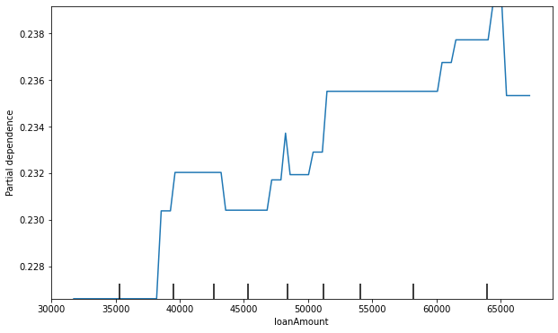

```python
PartialDependenceDisplay.from_estimator(best_grid_estimator, X_train, [1])
```

Theere is clearly a non-linear relationship between loanAmount and the probability of defaulting! Linear methods should not be used for this dataset!

### 5.4.2 Partial dependence plot for humanitarian studies

```
<sklearn.inspection._plot.partial_dependence.PartialDependenceDisplay at 0x23addfa5c08>
```

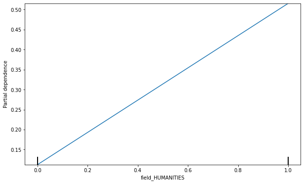

```python
PartialDependenceDisplay.from_estimator(best_grid_estimator, X_train, [4])
```

This confirms our findings from the exploratory data anayslsis section that students in Humanities tend to default significantly more often.

```python
y_train[X_train['field_HUMANITIES']==1].sum()/ len(y_train[X_train['field_HUMANITIES']==1])
```

```
0.6053921568627451
```

## 5.5 Partial dependence plot with more variables

```
<sklearn.inspection._plot.partial_dependence.PartialDependenceDisplay at 0x23ade651388>
```

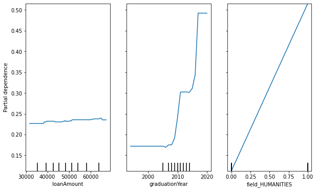

```python
PartialDependenceDisplay.from_estimator(best_grid_estimator, X_train, [1,2,4])
```

Again, this confirms the results from the exploratory data analysis section.

- It seems that as the loan amount increases to 60000 + the ML model predicts higher chance of defaulting
- If the graduation year is after 2010 the probability of defaulting raises significantly (for all fields)
- Students in humanitarian studies have a high expected probability of defaulting

## 5.6. 2D Partial Dependence plot

**Graduation Year vs. Loan Amount**

```
<sklearn.inspection._plot.partial_dependence.PartialDependenceDisplay at 0x23ade7e1448>
```

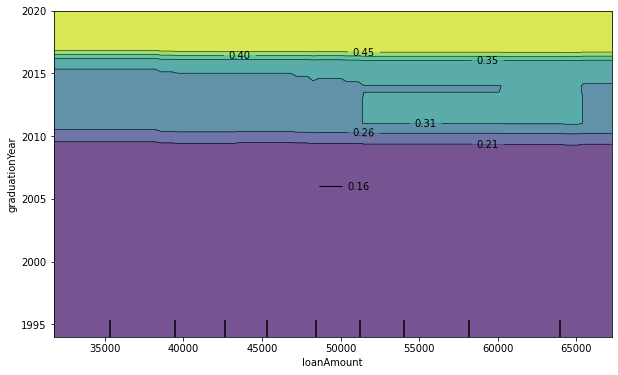

```python
PartialDependenceDisplay.from_estimator(best_grid_estimator, X_train, [[1,2]])
```

## 5.7 Permutation Feature Importance

Permutation feature importance overcomes two fundamental shortcomings of the previously used feature importance. Firstly, it scores the features based on the test set and not on the training set. In other words, the ranking of each feature represents the true predictive importance of that feature. Conversely, the Random Forest classfier's feature importance uses the training set. Therefore, it is possible that the algorithm picks up patterns in the feature space that do not actually influence the response variable significantly. Secondly, feature importance is prone to selecting features with high cardinality, that is many unique values, as the most importance ones.

Permutation Feature Importances are calculated in the following way. In each iteration one feature column in the test set gets permutated, such that it does not reflect any patterns observed previously. Then the trained model makes predictions using the permutated set. The difference between the missclassification error using the original test set and the permutated one, is an indicator of how important that variable is. The higher the difference, the more the predictive power of that feature.

```python
from sklearn.inspection import permutation_importance
```

```python
permutation_importances = permutation_importance(
    best_grid_estimator, X_test, y_test, n_repeats=20, random_state=2)
```

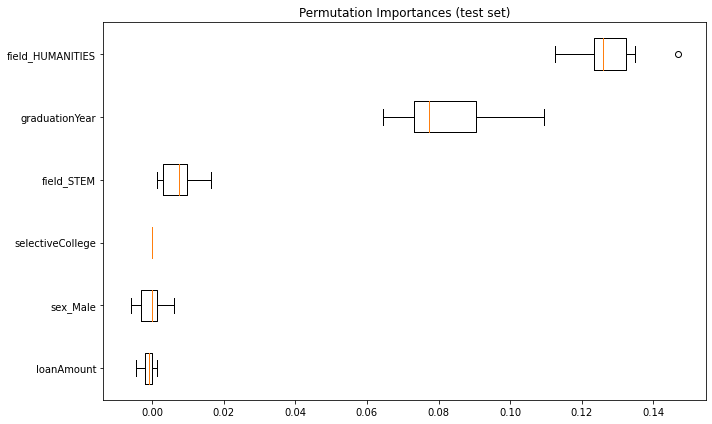

```python
sorted_idx = permutation_importances.importances_mean.argsort()

fig, ax = plt.subplots()
ax.boxplot(
    permutation_importances.importances[sorted_idx].T, vert=False, labels=X_test.columns[sorted_idx]
)
ax.set_title("Permutation Importances (test set)")
fig.tight_layout()
```

If we compare these results with `.feature_importances_` scores, we can see that whether the studies are humanitarian or not is consistently the feature with the highest predictive value. For the second place, in contrast, graduation year seems to have a significantly higher predictive power compared to whether a student studies in a STEM course or not as suggested by the `.feature_importances_` method. The rest of the features have an error difference very close to 0 which indicates that they are not that useful as features in this data set.